# R Notebook

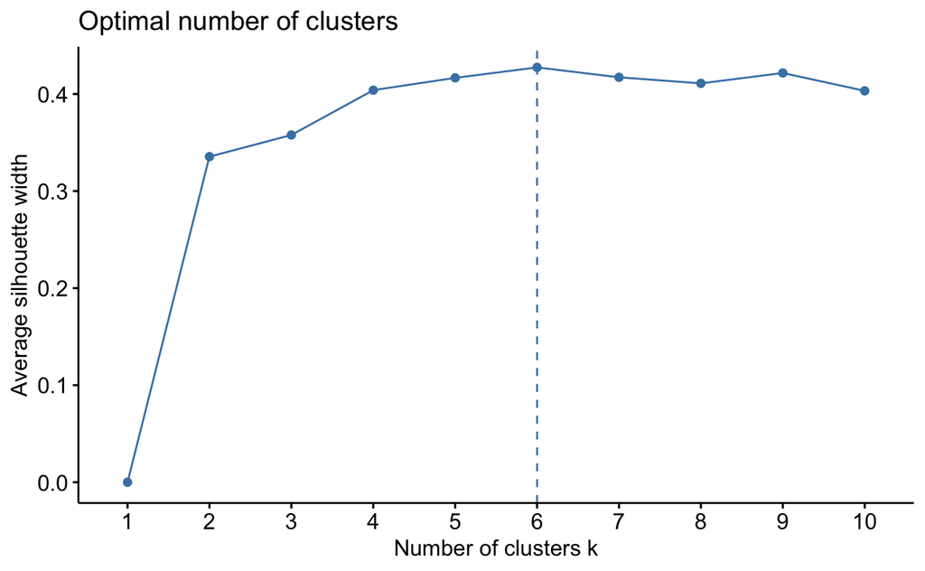

```r
fviz_nbclust(customer_scale,
             kmeans,
             method = "silhouette",
             nstart = 25)
```

```
Clustering k = 1,2,..., K.max (= 10): .. done
Bootstrapping, b = 1,2,..., B (= 100)  [one "." per sample]:
.................................................. 50
.................................................. 100
```

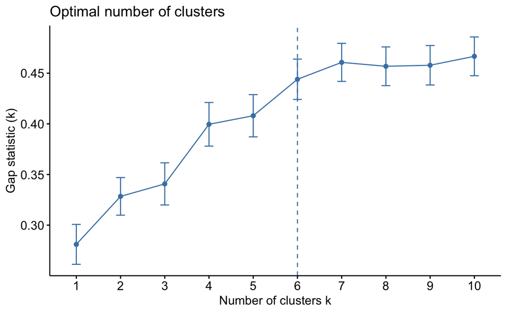

```r
fviz_nbclust(customer_scale,
             kmeans,
             method = "gap_stat",
             nstart = 25,
             k.max = 10)
```

Looks like 6 is the optimum number of clusters

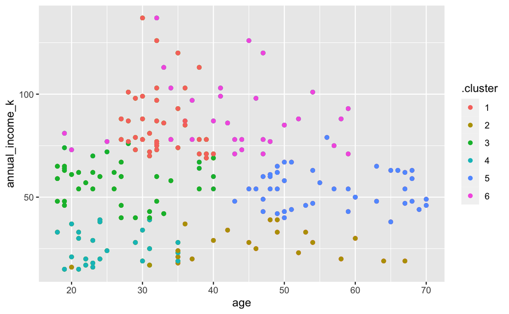

```r
 clusterings %>%
  unnest(cols = c(augmented)) %>%
  filter(k <= 6) %>%
  ggplot(aes(x = age, y = annual_income_k)) +
  geom_point(aes(color = .cluster))
```

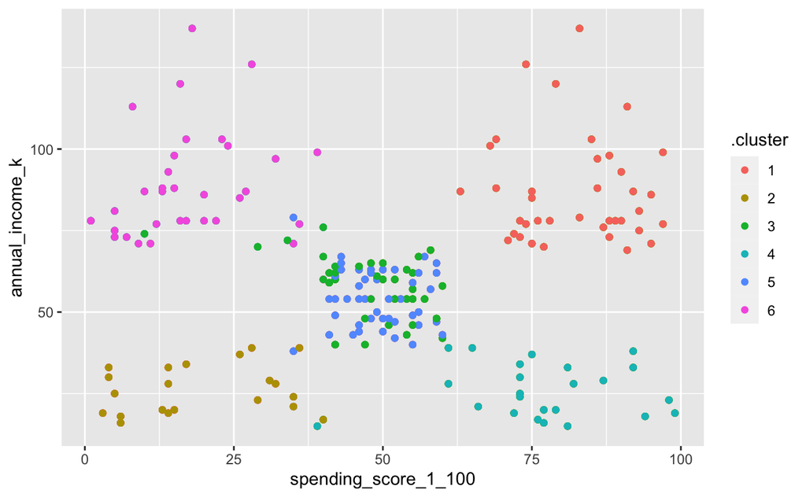

```r
 clusterings %>%
  unnest(cols = c(augmented)) %>%
  filter(k <= 6) %>%
  ggplot(aes(x = spending_score_1_100, y = annual_income_k)) +
  geom_point(aes(color = .cluster))
```

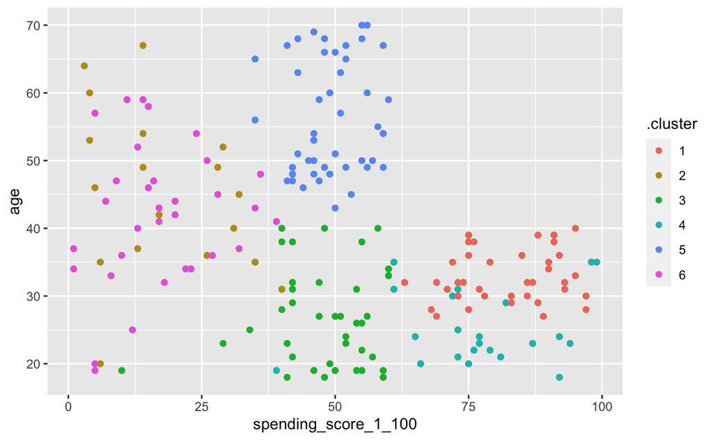

```r
 clusterings %>%
  unnest(cols = c(augmented)) %>%
  filter(k <= 6) %>%
  ggplot(aes(x = spending_score_1_100, y = age)) +
  geom_point(aes(color = .cluster))
```

The clusters are very clear to see on annual income vs spending score - and even suggest that 5 clusters might be more preferable. For the two graphs comparing age as well the clusters are less distinct - so perhaps age could be left out of the model.

Comment on the segments - changed to 5:

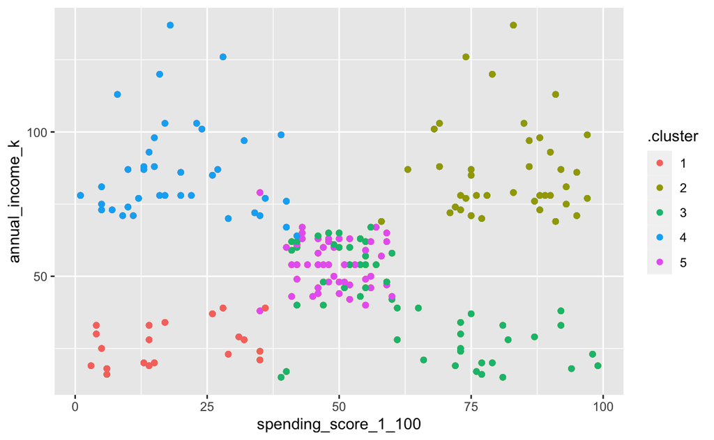

```r
 clusterings %>%
  unnest(cols = c(augmented)) %>%
  filter(k <= 5) %>%
  ggplot(aes(x = spending_score_1_100, y = annual_income_k)) +
  geom_point(aes(color = .cluster))
```

Changing to 5 clusters:

Cluster 1 - low income, low spending score

Cluster 2 - high income, high spending score

Cluster 4 - high income, low spending score

Cluster 5 - middle income, middle spending score

Copies of the clustered graphs (for reference):

[figure not shown]

[figure not shown]

[figure not shown]